# Use case 1: EBSeq vs. limma

Alyssa Frazee

January 5, 2014

Reviewer comment: *As far as I know, limma doesn’t account for the extra variability on isoform data, so it wouldn’t be an appropriate method to evaluate here (even as a proof-of-principle analysis). Therefore, I would suggest the authors to conduct the evaluations using isoform-level methods such as cuffdiff or EBSeq*

Here we re-run the analysis presented in the original manuscript, but use EBSeq to find isoform-level differential expression instead of limma. The results from EBSeq are very similar to the results from limma, indicating that in this particular scenario (where isoform-level differential expression was known to exist in the data), either limma or EBSeq is an appropriate method for finding differential transcript expression.

First we load in the R packages needed and read in the data (isoform-level expression estimated with Cufflinks):

```r
library(EBSeq)
library(limma)
s1 = read.table(
    'de_experiment/assemblies/large_variance/sample01/isoforms.fpkm_tracking',
    header=TRUE)
transcripts = s1$tracking_id
fpkm_large = fpkm_small = matrix(NA, nrow=length(unique(transcripts)), ncol=14)
rn = unique(transcripts)
rownames(fpkm_large) = rownames(fpkm_small) = transcripts

fpkm_large[,1] = s1$FPKM

for(i in 1:14){
    istring = formatC(i, width=2, format="d", flag="0")
    if(i>1){
        largedat = read.table(paste0('de_experiment/assemblies/large_variance/sample',
            istring, '/isoforms.fpkm_tracking'), header=TRUE)
        meas = largedat$FPKM[match(rownames(fpkm_large), largedat$tracking_id)]
        fpkm_large[,i] = meas
    }
    smalldat = read.table(paste0('de_experiment/assemblies/small_variance/sample',
        istring, '/isoforms.fpkm_tracking'), header=TRUE)
    meas = smalldat$FPKM[match(rownames(fpkm_small), smalldat$tracking_id)]
    fpkm_small[,i] = meas
}
```

Now we use these FPKM estimates to find differentially-expressed isoforms with limma:

```r
lib_adjust = apply(fpkm_large, 2, function(x){
    quantile(log2(x+1), 0.75)
})
y = log2(fpkm_large+1)
trt = rep(c(1,0), each=7)
x = model.matrix(~ trt + lib_adjust)
fit = lmFit(y, x)
fit = eBayes(fit, trend=TRUE)
pvals = fit$p.value[,2]
qvals = p.adjust(pvals, 'fdr')

siminfo = read.table('de_experiment/reads/large_variance/sim_tx_info.txt', header=TRUE)
reallyde = siminfo[siminfo$DEstatus,]$transcriptid
notde = siminfo[!siminfo$DEstatus,]$transcriptid

qaxis = seq(0,1,by=0.01)
sens=spec=NULL
for(i in seq_along(qaxis)){
    sens[i] = sum(reallyde %in% names(qvals[qvals<qaxis[i]])) / length(reallyde)
    spec[i] = sum(notde %in% names(qvals[qvals>=qaxis[i]])) / length(notde)
}

### small variance:
lib_adjust = apply(fpkm_small, 2, function(x){
    quantile(log2(x+1), 0.75)
})
y = log2(fpkm_small+1)
fit = lmFit(y, x)
fit = eBayes(fit, trend=TRUE)
pvals2 = fit$p.value[,2]
qvals2 = p.adjust(pvals2, 'fdr')

siminfo = read.table('de_experiment/reads/small_variance/sim_tx_info.txt', header=TRUE)
reallyde = siminfo[siminfo$DEstatus,]$transcriptid
notde = siminfo[!siminfo$DEstatus,]$transcriptid

qaxis = seq(0,1,by=0.01)
sens2 = spec2 = NULL
for(i in seq_along(qaxis)){
    sens2[i] = sum(reallyde %in% names(qvals2[qvals2<qaxis[i]])) / length(reallyde)
    spec2[i] = sum(notde %in% names(qvals2[qvals2>=qaxis[i]])) / length(notde)
}
```

And then we use the same FPKM estimates to find differentially-expressed isoforms with EBSeq:

```r
Conditions = rep(c('case', 'control'), each=7)
IsoformNames = rownames(fpkm_small)
iso_gene_relationship = read.table('de_experiment/assemblies/small_variance/sample01/isoforms.fpkm_tracking', header=TRUE, colClasses=c('character', 'NULL' ,'NULL', 'character', rep('NULL', 9)))
iso_gene_relationship = iso_gene_relationship[match(IsoformNames, iso_gene_relationship$tracking_id),]
sum(IsoformNames != iso_gene_relationship$tracking_id) # expect 0
```

```
## [1] 0
```

```r
IsosGeneNames = iso_gene_relationship$gene_id
IsoSizes = MedianNorm(fpkm_small)
NgList = GetNg(IsoformNames, IsosGeneNames)
IsoNgTrun = NgList$IsoformNgTrun
# ebseq: small variance
IsoEBOut = EBTest(Data=fpkm_small, NgVector=IsoNgTrun,
    Conditions=as.factor(Conditions), sizeFactors=IsoSizes, maxround=20)
```

```
## Removing transcripts with 75 th quantile < = 10
## 905 transcripts will be tested
```

[output not shown]

[output cut: 24 more lines]

[output not shown]

```r
fcsmall = PostFC(IsoEBOut, SmallNum=1)

# ebseq: large variance
sum(rownames(fpkm_small) != rownames(fpkm_large)) #expect 0
```

```
## [1] 0
```

```r
IsoSizes = MedianNorm(fpkm_large)
IsoEBOut_large = EBTest(Data=fpkm_large, NgVector=IsoNgTrun,
    Conditions = as.factor(Conditions), sizeFactors=IsoSizes, maxround=20)
```

```
## Removing transcripts with 75 th quantile < = 10
## 908 transcripts will be tested
```

[output not shown]

[output cut: 24 more lines]

[output not shown]

```r
fclarge = PostFC(IsoEBOut_large, SmallNum=1)

ppde_large = IsoEBOut_large$PPDE
qaxis = rev(seq(0,1,by=0.01))
ebsens=ebspec=NULL
for(i in seq_along(qaxis)){
    ebsens[i] = sum(reallyde %in% names(ppde_large[ppde_large>qaxis[i]])) / length(reallyde)
    ebspec[i] = sum(notde %in% c(names(ppde_large[ppde_large<=qaxis[i]]), setdiff(notde, names(ppde_large)))) / length(notde)
}

### small variance:
ppde_small = IsoEBOut$PPDE
ebsens2 = ebspec2 = NULL
for(i in seq_along(qaxis)){
    ebsens2[i] = sum(reallyde %in% names(ppde_small[ppde_small>qaxis[i]])) / length(reallyde)
    ebspec2[i] = sum(notde %in% c(names(ppde_small[ppde_small<=qaxis[i]]), setdiff(notde, names(ppde_small)))) / length(notde)
}
```

And here we add the sensitivity and specificity estimates from EBSeq to the ROC curve presented in the original manuscript (Figure 4). For limma, we vary the q-value cutoff to calculate sensitivity and specificity, and for EBSeq, we vary the posterior probability of being differentially expressed.

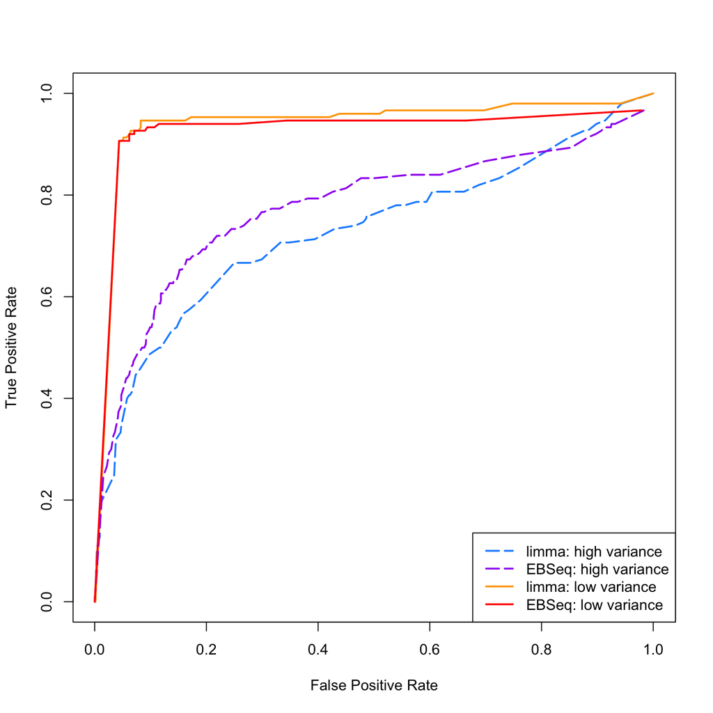

```r
plot(1-spec, sens, type='l', xlab='False Positive Rate',
    ylab='True Positive Rate', col='dodgerblue', lwd=2, lty=5)
lines(1-spec2, sens2, col='orange', lwd=2)
lines(1-ebspec, ebsens, col='purple', lwd=2, lty=5)
lines(1-ebspec2, ebsens2, col='red', lwd=2)
legend('bottomright', lty=c(5,5,1,1), lwd=2,
    col=c('dodgerblue','purple','orange','red'),
    c('limma: high variance', 'EBSeq: high variance', 'limma: low variance', 'EBSeq: low variance'))
```

Next, we re-create the density plots presented in the original manuscript (Figure 5), but add densities from the EBSeq posterior fold change estimates.

```r
# limma coefficients
coefs_small = fit$coefficients[,2]
lib_adjust = apply(fpkm_large, 2, function(x){
    quantile(log2(x+1), 0.75)
})
y = log2(fpkm_large+1)
fit = lmFit(y, x)
fit = eBayes(fit, trend=TRUE)
coefs_large = fit$coefficients[,2]

nonde_inds = which(names(coefs_small) %in% notde)
up_inds = which(names(coefs_small) %in% siminfo$transcriptid[siminfo$foldchange>1])
down_inds = which(names(coefs_small) %in% siminfo$transcriptid[siminfo$foldchange<1])
stopifnot(sum(names(coefs_small) != names(coefs_large)) == 0)
mean(coefs_large[up_inds])
```

```
## [1] 1.390997
```

```r
mean(coefs_large[down_inds])
```

```
## [1] -1.570012
```

```r
mean(coefs_small[up_inds])
```

```
## [1] 1.437899
```

```r
mean(coefs_small[down_inds])
```

```
## [1] -1.597739
```

```r
par(mfrow=c(1,2))
plot(density(coefs_large[nonde_inds]), col='blue', lwd=2,
    xlab='Fitted Coefficient (log scale)', ylim=c(0, 0.65),
    main='(a) Large variance scenario', xlim=c(-6, 9))
lines(density(coefs_large[up_inds]), col='deepskyblue', lwd=2)
lines(density(coefs_large[down_inds]), col='navy', lwd=2)

coefs_large = fclarge$PostFC
nonde_inds = which(names(coefs_large) %in% notde)
up_inds = which(names(coefs_large) %in% siminfo$transcriptid[siminfo$foldchange>1])
down_inds = which(names(coefs_large) %in% siminfo$transcriptid[siminfo$foldchange<1])
mean(log2(coefs_large[up_inds]))
```

```
## [1] 1.439288
```

```r
mean(log2(coefs_large[down_inds]))
```

```
## [1] -1.490897
```

```r
lines(density(log2(coefs_large[nonde_inds])), col='blue', lwd=2, lty=3)
lines(density(log2(coefs_large[up_inds])), col='deepskyblue', lwd=2, lty=3)
lines(density(log2(coefs_large[down_inds])), col='navy', lwd=2, lty=3)
legend('topright', c('underexpressed', 'not DE', 'overexpressed', 'limma', 'EBSeq'),
    col=c('navy','blue','deepskyblue','gray','gray'), lwd=2, lty=c(1,1,1,1,3), cex=0.5)

nonde_inds = which(names(coefs_small) %in% notde)
up_inds = which(names(coefs_small) %in% siminfo$transcriptid[siminfo$foldchange>1])
down_inds = which(names(coefs_small) %in% siminfo$transcriptid[siminfo$foldchange<1])
plot(density(coefs_small[nonde_inds]), col='blue', lwd=2,
    xlab='Fitted Coefficient (log scale)', ylim=c(0, 4),
    main='(b) Small variance scenario', xlim=c(-6, 9))
lines(density(coefs_small[up_inds]), col='deepskyblue', lwd=2)
lines(density(coefs_small[down_inds]), col='navy', lwd=2)

fcsmall = PostFC(IsoEBOut, SmallNum=1)
coefs_small = fcsmall$PostFC
nonde_inds = which(names(coefs_small) %in% notde)
up_inds = which(names(coefs_small) %in% siminfo$transcriptid[siminfo$foldchange>1])
down_inds = which(names(coefs_small) %in% siminfo$transcriptid[siminfo$foldchange<1])
mean(log2(coefs_small[up_inds]))
```

```
## [1] 1.490146
```

```r
mean(log2(coefs_small[down_inds]))
```

```
## [1] -1.589515
```

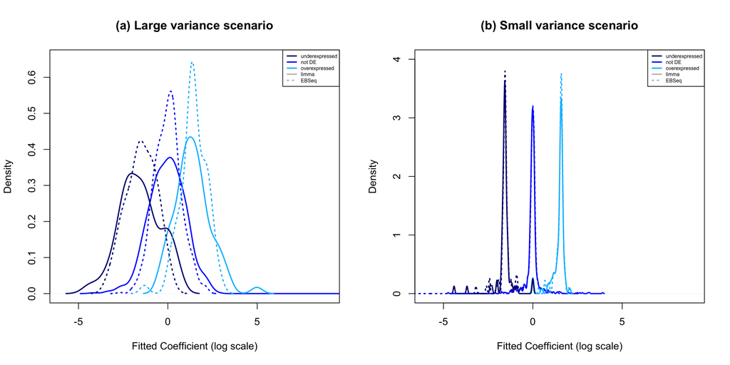

```r
lines(density(log2(coefs_small[nonde_inds])), col='blue', lwd=2, lty=3)
lines(density(log2(coefs_small[up_inds])), col='deepskyblue', lwd=2, lty=3)
lines(density(log2(coefs_small[down_inds])), col='navy', lwd=2, lty=3)
legend('topright', c('underexpressed', 'not DE', 'overexpressed', 'limma', 'EBSeq'),
    col=c('navy','blue','deepskyblue','gray','gray'), lwd=2, lty=c(1,1,1,1,3), cex=0.5)
```